# Mozilla Data Science Project - 2019

Mariana de Oliveira Santos Silva

December 05, 2019

# Exploratory Data Analysis (EDA)

This R markdown covers the Exploratory Data Analysis (EDA) on the training dataset of the PRD.

## Setting-up

```r
## Loading the needed libraries

library(kableExtra)      # help you build common complex tables and manipulate table styles
library(tidyverse)       # for general data wrangling (includes readr and dplyr)
library(ggplot2)         # to draw statistical plots
library(plotly)          # to construct interactive 3d plots
library(DataExplorer)    # automated data exploration
library(corrplot)        # to plot nice correlation matrix
library(caret)           # includes several functions to pre-process
library(scales)          # to determining breaks and labels for axes and legends
library(skimr)
library(funModeling)
library(Hmisc)
library(grid)
library(hrbrthemes)
library(tidyr)
library(viridis)
library(ggpubr)
library(ggthemes)
library(GGally)
```

```r
## Loading the training dataset

load("~/GitHub/ff-beta-release-matching/poc/EDA/data_milestone2_df_train_validate_20191025.RData")
```

```r
## View train dataframe

kable(head(df_train_f)) %>%
kable_styling(bootstrap_options = c("striped", "hover", "condensed"), full_width = F) %>%
scroll_box(width = "100%")
```

| client_id | num_active_days | content_crashes | active_hours | uri_count | session_length | search_count | num_bookmarks | num_pages | daily_unique_domains | daily_max_tabs | daily_tabs_opened | startup_ms | daily_num_sessions_started | active_hours_max | uri_count_max | session_length_max | search_count_max | num_pages_max | daily_unique_domains_max | daily_max_tabs_max | daily_tabs_opened_max | startup_ms_max | daily_num_sessions_started_max | label | install_year | profile_age | fxa_configured | sync_configured | is_default_browser | … |
| --- | --- | --- | --- | --- | --- | --- | --- | --- | --- | --- | --- | --- | --- | --- | --- | --- | --- | --- | --- | --- | --- | --- | --- | --- | --- | --- | --- | --- | --- | --- |
| 001cf926-92e3-4587-887e-d3156ba24d82 | 8 | 0 | 1.4215278 | 76.1250 | 22.9337499 | 1.875 | 11.00 | 4014.5 | 6.062500 | 7.00000 | 15.00 | 54176.2500 | 0.6250000 | 3.3208333 | 139 | 37.007500 | 6 | 15464 | 17.000000 | 11 | 29 | 180095 | 2 | beta | 2016 | 1160 | False | False | True | … |
| 00210163-2123-427e-bb73-398bda9f9eba | 5 | 0 | 0.8305556 | 168.2000 | 2.4390556 | 0.800 | 248.75 | 20599.5 | 7.866667 | 3.40000 | 14.80 | 3164.0667 | 1.2000000 | 1.6708333 | 325 | 8.318333 | 3 | 20719 | 17.000000 | 4 | 33 | 4966 | 2 | beta | 2016 | 1079 | False | False | False | … |
| 0024fd24-4ef5-4771-850a-9e3846597015 | 2 | 0 | 0.5111111 | 82.0000 | 0.8712505 | 2.500 | 9.00 | 87.0 | 2.166667 | 4.00000 | 8.00 | 23977.9444 | 5.0000000 | 0.8250000 | 145 | 1.464445 | 5 | 87 | 3.333333 | 6 | 15 | 31918 | 9 | beta | 2019 | 745 | False | False | True | … |
| 004f70f7-2576-4de5-94b4-5bf1acdca0a8 | 8 | 0 | 0.3946181 | 101.8750 | 4.6785415 | 7.750 | 87.00 | 8882.0 | 7.750000 | 9.25000 | 19.50 | 1703.3125 | 1.3750000 | 1.1625000 | 210 | 9.174722 | 10 | 9044 | 13.000000 | 12 | 37 | 3454 | 2 | beta | 2018 | 130 | True | True | True | … |
| 007c0c11-38e4-476b-a494-d732e15ac159 | 4 | 0 | 0.5930556 | 167.5000 | 5.6081245 | 0.250 | 13.00 | 3024.0 | 1.775000 | 8.75000 | 13.75 | 15285.5375 | 2.2500000 | 0.8791667 | 255 | 9.059722 | 1 | 3552 | 2.500000 | 27 | 36 | 24592 | 3 | beta | 2018 | 293 | False | False | False | … |
| 0294837f-c98f-44ab-8237-30d2eba6c55a | 6 | 0 | 1.6333333 | 165.8333 | 32.4127778 | 5.500 | 17.00 | 7740.7 | 8.583333 | 10.33333 | 20.00 | 975.2222 | 0.1666667 | 3.2319444 | 323 | 41.553611 | 12 | 7975 | 13.000000 | 18 | 35 | 1088 | 1 | beta | 2019 | 502 | False | False | True | … |

## Step 1 : Data Inspection

To get introduced to our dataset, et’s have a look on the basic information of the dataset.

| rows | columns | discrete_columns | continuous_columns | all_missing_columns | total_missing_values | complete_rows | total_observations | memory_usage |
| --- | --- | --- | --- | --- | --- | --- | --- | --- |
| 302819 | 58 | 20 | 38 | 0 | 0 | 302819 | 17563502 | 135686992 |

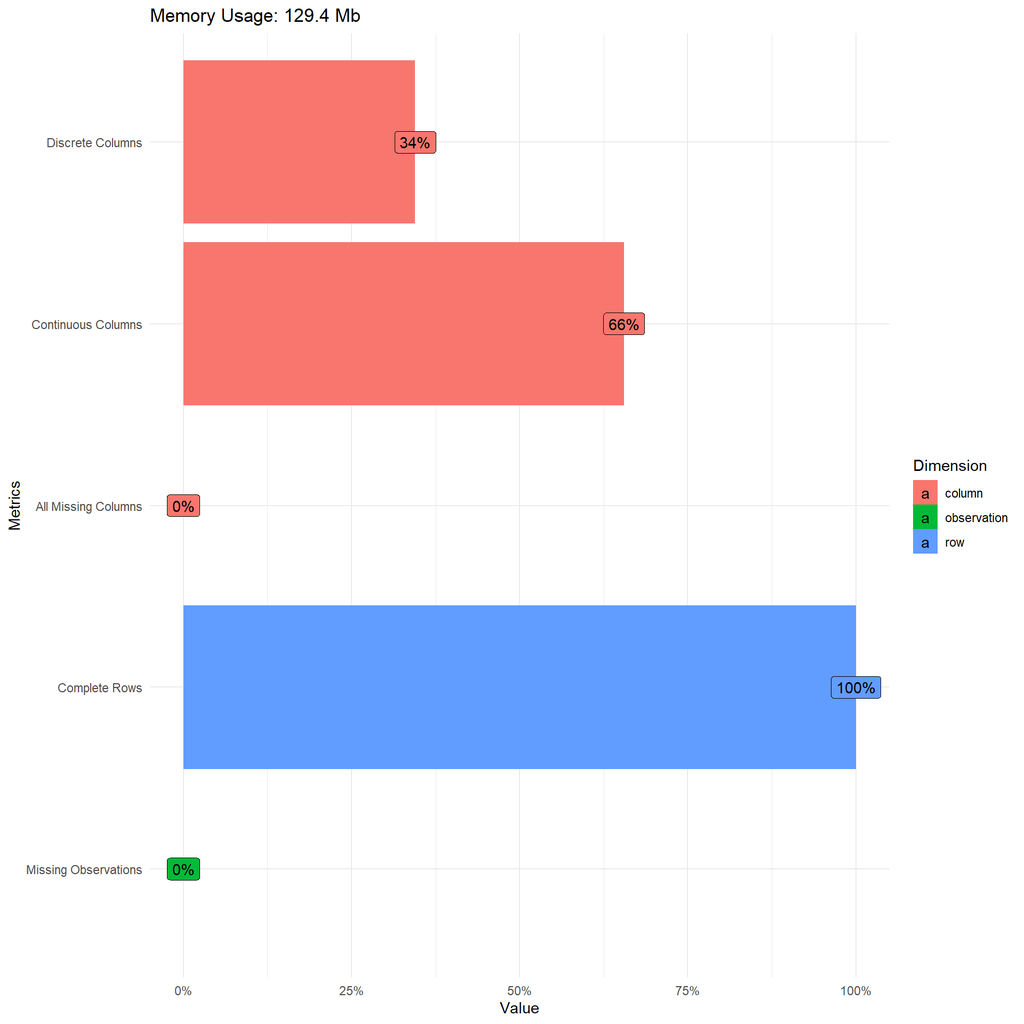

### Observations

- Most of the dataset is composed of continuous variables
- No NAs values (were handled in preprocessing)

### Structure

Let’s use `glimpse` function to display a vertical preview of the dataset. So we can easily preview data type and sample data.

```r
glimpse(df_train_f)
```

```
## Observations: 302,819
## Variables: 58
## $ client_id                         <chr> "001cf926-92e3-4587-887e-d31...
## $ num_active_days                   <int> 8, 5, 2, 8, 4, 6, 8, 4, 3, 5...
## $ content_crashes                   <int> 0, 0, 0, 0, 0, 0, 0, 0, 0, 0...
## $ active_hours                      <dbl> 1.42152778, 0.83055556, 0.51...
## $ uri_count                         <dbl> 76.12500, 168.20000, 82.0000...
## $ session_length                    <dbl> 22.93374988, 2.43905560, 0.8...
## $ search_count                      <dbl> 1.875000, 0.800000, 2.500000...
## $ num_bookmarks                     <dbl> 11.00, 248.75, 9.00, 87.00, ...
## $ num_pages                         <dbl> 4014.5000, 20599.5000, 87.00...
## $ daily_unique_domains              <dbl> 6.062500, 7.866667, 2.166667...
## $ daily_max_tabs                    <dbl> 7.000000, 3.400000, 4.000000...
## $ daily_tabs_opened                 <dbl> 15.000000, 14.800000, 8.0000...
## $ startup_ms                        <dbl> 54176.2500, 3164.0667, 23977...
```

[output cut: 45 more lines]

If we want to get some metrics about data types, zeros, infinite numbers, and missing values, we can use the `df_status` function.

```r
kable(df_status(df_train_f, FALSE)) %>%
kable_styling(bootstrap_options = c("striped", "hover", "condensed"), full_width = F) %>%
scroll_box(width = "100%")
```

| variable | q_zeros | p_zeros | q_na | p_na | q_inf | p_inf | type | unique |
| --- | --- | --- | --- | --- | --- | --- | --- | --- |
| client_id | 0 | 0.00 | 0 | 0 | 0 | 0 | character | 302805 |
| num_active_days | 0 | 0.00 | 0 | 0 | 0 | 0 | integer | 8 |
| content_crashes | 302819 | 100.00 | 0 | 0 | 0 | 0 | integer | 1 |
| active_hours | 7 | 0.00 | 0 | 0 | 0 | 0 | numeric | 180711 |
| uri_count | 0 | 0.00 | 0 | 0 | 0 | 0 | numeric | 18610 |
| session_length | 0 | 0.00 | 0 | 0 | 0 | 0 | numeric | 289472 |
| search_count | 80328 | 26.53 | 0 | 0 | 0 | 0 | numeric | 930 |
| num_bookmarks | 472 | 0.16 | 0 | 0 | 0 | 0 | numeric | 19727 |
| num_pages | 7 | 0.00 | 0 | 0 | 0 | 0 | numeric | 179391 |
| daily_unique_domains | 0 | 0.00 | 0 | 0 | 0 | 0 | numeric | 66058 |
| daily_max_tabs | 0 | 0.00 | 0 | 0 | 0 | 0 | numeric | 2888 |
| daily_tabs_opened | 0 | 0.00 | 0 | 0 | 0 | 0 | numeric | 4645 |
| startup_ms | 0 | 0.00 | 0 | 0 | 0 | 0 | numeric | 276270 |
| daily_num_sessions_started | 3100 | 1.02 | 0 | 0 | 0 | 0 | numeric | 654 |
| active_hours_max | 7 | 0.00 | 0 | 0 | 0 | 0 | numeric | 39216 |
| uri_count_max | 0 | 0.00 | 0 | 0 | 0 | 0 | integer | 3642 |
| session_length_max | 0 | 0.00 | 0 | 0 | 0 | 0 | numeric | 188078 |
| search_count_max | 80328 | 26.53 | 0 | 0 | 0 | 0 | integer | 140 |
| num_pages_max | 7 | 0.00 | 0 | 0 | 0 | 0 | numeric | 76011 |
| daily_unique_domains_max | 0 | 0.00 | 0 | 0 | 0 | 0 | numeric | 1996 |
| daily_max_tabs_max | 0 | 0.00 | 0 | 0 | 0 | 0 | integer | 541 |
| daily_tabs_opened_max | 0 | 0.00 | 0 | 0 | 0 | 0 | integer | 853 |
| startup_ms_max | 0 | 0.00 | 0 | 0 | 0 | 0 | numeric | 145192 |
| daily_num_sessions_started_max | 3100 | 1.02 | 0 | 0 | 0 | 0 | integer | 85 |
| label | 0 | 0.00 | 0 | 0 | 0 | 0 | factor | 2 |
| install_year | 0 | 0.00 | 0 | 0 | 0 | 0 | numeric | 21 |
| profile_age | 6320 | 2.09 | 0 | 0 | 0 | 0 | numeric | 4127 |
| fxa_configured | 0 | 0.00 | 0 | 0 | 0 | 0 | factor | 2 |
| sync_configured | 0 | 0.00 | 0 | 0 | 0 | 0 | factor | 2 |
| is_default_browser | 0 | 0.00 | 0 | 0 | 0 | 0 | factor | 2 |
| locale | 0 | 0.00 | 0 | 0 | 0 | 0 | factor | 2 |
| normalized_channel | 0 | 0.00 | 0 | 0 | 0 | 0 | factor | 2 |
| app_version | 0 | 0.00 | 0 | 0 | 0 | 0 | numeric | 1 |
| default_search_engine | 0 | 0.00 | 0 | 0 | 0 | 0 | factor | 6 |
| country | 0 | 0.00 | 0 | 0 | 0 | 0 | factor | 2 |
| timezone_offset | 736 | 0.24 | 0 | 0 | 0 | 0 | integer | 35 |
| num_addons | 53 | 0.02 | 0 | 0 | 0 | 0 | numeric | 2124 |
| cpu_cores | 0 | 0.00 | 0 | 0 | 0 | 0 | numeric | 27 |
| cpu_speed_mhz | 0 | 0.00 | 0 | 0 | 0 | 0 | numeric | 1232 |
| cpu_l2_cache_kb | 0 | 0.00 | 0 | 0 | 0 | 0 | numeric | 8 |
| cpu_vendor | 0 | 0.00 | 0 | 0 | 0 | 0 | factor | 3 |
| memory_mb | 0 | 0.00 | 0 | 0 | 0 | 0 | integer | 5893 |
| os_version | 0 | 0.00 | 0 | 0 | 0 | 0 | ordered-factor | 5 |
| is_wow64 | 0 | 0.00 | 0 | 0 | 0 | 0 | factor | 2 |
| FX_PAGE_LOAD_MS_2_PARENT | 0 | 0.00 | 0 | 0 | 0 | 0 | numeric | 294778 |
| TIME_TO_DOM_COMPLETE_MS | 0 | 0.00 | 0 | 0 | 0 | 0 | numeric | 300964 |
| TIME_TO_DOM_CONTENT_LOADED_END_MS | 0 | 0.00 | 0 | 0 | 0 | 0 | numeric | 300503 |
| TIME_TO_LOAD_EVENT_END_MS | 0 | 0.00 | 0 | 0 | 0 | 0 | numeric | 301045 |
| TIME_TO_DOM_INTERACTIVE_MS | 0 | 0.00 | 0 | 0 | 0 | 0 | numeric | 300036 |
| TIME_TO_NON_BLANK_PAINT_MS | 0 | 0.00 | 0 | 0 | 0 | 0 | numeric | 296802 |
| profile_age_cat | 0 | 0.00 | 0 | 0 | 0 | 0 | ordered-factor | 6 |
| distro_id_norm | 0 | 0.00 | 0 | 0 | 0 | 0 | factor | 4 |
| timezone_cat | 0 | 0.00 | 0 | 0 | 0 | 0 | factor | 13 |
| memory_cat | 0 | 0.00 | 0 | 0 | 0 | 0 | ordered-factor | 6 |
| cpu_speed_cat | 0 | 0.00 | 0 | 0 | 0 | 0 | ordered-factor | 5 |
| cpu_cores_cat | 0 | 0.00 | 0 | 0 | 0 | 0 | ordered-factor | 6 |
| is_release | 59627 | 19.69 | 0 | 0 | 0 | 0 | logical | 2 |
| cpu_l2_cache_kb_cat | 0 | 0.00 | 0 | 0 | 0 | 0 | factor | 4 |

- `q_zeros`: quantity of zeros (`p_zeros`: in percent)
- `q_inf`: quantity of infinite values (`p_inf`: in percent)
- `q_na`: quantity of NA (`p_na`: in percent)
- `type`: factor, ordered-factor, numeric, integer or character
- `unique`: quantity of unique values

#### Observations

> Are all the variables in the correct data type?

None. It seems that this has already been dealt with in preprocessing.

> Any variables with lots of zeros?

Yes. Variables with lots of zeros may not be useful for modeling and, in some cases, they may dramatically bias the model. For example, the `content_crashes` is 100% equal to zero.

> Any variables with lots of NAs?

None. Good news.

> Any high cardinality variable?

Factor/categorical variables with a high number of different values (~30) tend to do overfitting if the categories have low cardinality.

## Step 2 : Beta vs Release

```r
df_release <- df_train_f[which(df_train_f$label == 'release'), ]
df_beta <- df_train_f[which(df_train_f$label == 'beta'), ]

f <- freq(df_train_f$label)
```

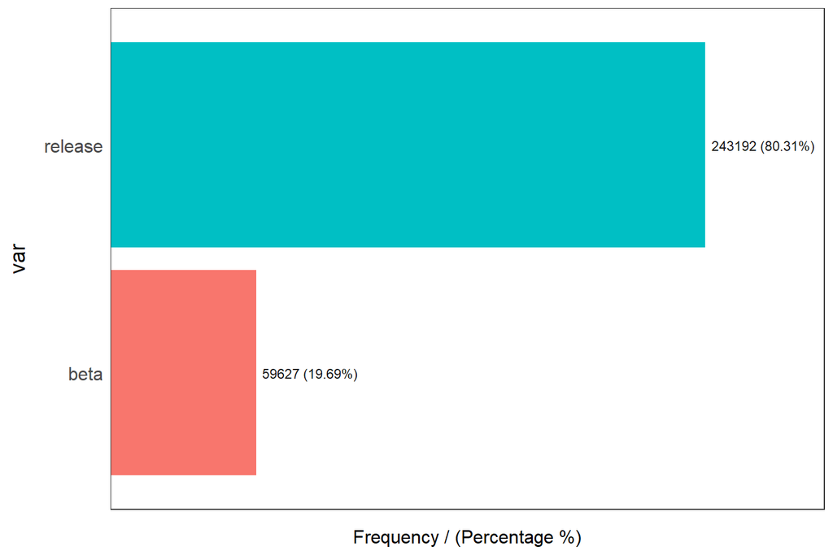

```r
summary(df_release)
```

```
##   client_id         num_active_days content_crashes  active_hours
##  Length:243192      Min.   :1.00    Min.   :0       Min.   :0.0000
##  Class :character   1st Qu.:4.00    1st Qu.:0       1st Qu.:0.2686
##  Mode  :character   Median :6.00    Median :0       Median :0.5744
##                     Mean   :5.57    Mean   :0       Mean   :0.8469
##                     3rd Qu.:8.00    3rd Qu.:0       3rd Qu.:1.1266
##                     Max.   :8.00    Max.   :0       Max.   :7.1222
##
##    uri_count       session_length      search_count    num_bookmarks
##  Min.   :   1.00   Min.   : 0.01926   Min.   : 0.000   Min.   :    0.00
##  1st Qu.:  44.33   1st Qu.: 2.15904   1st Qu.: 0.000   1st Qu.:   10.00
##  Median :  96.67   Median : 6.33512   Median : 0.875   Median :   26.00
##  Mean   : 156.24   Mean   : 9.28218   Mean   : 2.377   Mean   :  158.94
##  3rd Qu.: 197.00   3rd Qu.:13.66085   3rd Qu.: 3.000   3rd Qu.:   85.21
##  Max.   :2391.25   Max.   :91.06639   Max.   :45.750   Max.   :18632.00
##
##    num_pages      daily_unique_domains daily_max_tabs    daily_tabs_opened
##  Min.   :     0   Min.   : 1.000       Min.   :  0.625   Min.   :  1.000
##  1st Qu.:  1022   1st Qu.: 2.283       1st Qu.:  2.500   1st Qu.:  4.000
##  Median :  5536   Median : 3.600       Median :  3.714   Median :  8.833
##  Mean   : 17331   Mean   : 4.968       Mean   :  6.200   Mean   : 17.093
##  3rd Qu.: 19681   3rd Qu.: 6.071       3rd Qu.:  6.000   3rd Qu.: 19.167
##  Max.   :168416   Max.   :39.375       Max.   :445.375   Max.   :347.500
##
##    startup_ms      daily_num_sessions_started active_hours_max
##  Min.   :    261   Min.   : 0.000             Min.   : 0.0000
##  1st Qu.:   1433   1st Qu.: 1.250             1st Qu.: 0.5403
##  Median :   3231   Median : 2.000             Median : 1.1542
##  Mean   :   9832   Mean   : 2.889             Mean   : 1.6251
##  3rd Qu.:   8395   3rd Qu.: 3.500             3rd Qu.: 2.1903
##  Max.   :5358123   Max.   :32.250             Max.   :23.9667
##
##  uri_count_max     session_length_max search_count_max  num_pages_max
##  Min.   :    1.0   Min.   :  0.0306   Min.   :  0.000   Min.   :     0
##  1st Qu.:   86.0   1st Qu.:  4.4085   1st Qu.:  0.000   1st Qu.:  1142
##  Median :  196.0   Median : 11.7017   Median :  2.000   Median :  5706
##  Mean   :  321.4   Mean   : 18.2107   Mean   :  5.434   Mean   : 17519
##  3rd Qu.:  400.0   3rd Qu.: 26.1284   3rd Qu.:  7.000   3rd Qu.: 19922
##  Max.   :18032.0   Max.   :384.2883   Max.   :217.000   Max.   :172543
##
```

[output cut: 81 more lines]

```
##  acer   :  2619   (-6,-4]  :146732   < 1GB :   346   < 1GHz :   452
##  Mozilla:237022   (-8,-6]  : 54613   < 2GB :  5534   < 2GHz : 38361
##  other  :  2351   (0,2]    : 35955   < 4GB : 66120   < 3GHz :123428
##  Yahoo  :  1200   (4,6]    :  2165   < 6GB : 15982   < 4GHz : 76780
##                   [-12,-10]:   958   < 16GB:144433   > 16GHz:  4171
##                   (6,8]    :   870   > 16GB: 10777
##                   (Other)  :  1899
##  cpu_cores_cat is_release     cpu_l2_cache_kb_cat
##  1   :  3122   Mode:logical   < 1024: 22370
##  2   :120526   TRUE:243192    < 256 :179679
##  < 4 :104846                  < 512 : 13262
##  < 8 : 13778                  > 1024: 27881
##  < 16:   745
##  > 16:   175
##
```

```r
summary(df_beta)
```

```
##   client_id         num_active_days content_crashes  active_hours
##  Length:59627       Min.   :1.000   Min.   :0       Min.   :0.0000
##  Class :character   1st Qu.:4.000   1st Qu.:0       1st Qu.:0.2250
##  Mode  :character   Median :6.000   Median :0       Median :0.5310
##                     Mean   :5.346   Mean   :0       Mean   :0.8237
##                     3rd Qu.:8.000   3rd Qu.:0       3rd Qu.:1.1029
##                     Max.   :8.000   Max.   :0       Max.   :7.2901
##
##    uri_count       session_length       search_count     num_bookmarks
##  Min.   :   1.00   Min.   :  0.01667   Min.   : 0.0000   Min.   :    0.0
##  1st Qu.:  37.00   1st Qu.:  2.52840   1st Qu.: 0.0000   1st Qu.:   10.0
##  Median :  86.67   Median :  7.71056   Median : 0.8333   Median :   26.0
##  Mean   : 152.75   Mean   : 12.29620   Mean   : 2.4506   Mean   :  242.5
##  3rd Qu.: 188.50   3rd Qu.: 19.57926   3rd Qu.: 2.8333   3rd Qu.:   96.0
##  Max.   :2931.00   Max.   :240.80486   Max.   :51.0000   Max.   :40401.0
##
##    num_pages      daily_unique_domains daily_max_tabs
##  Min.   :     1   Min.   : 1.000       Min.   :   1.000
##  1st Qu.:   686   1st Qu.: 2.167       1st Qu.:   2.600
##  Median :  4186   Median : 3.562       Median :   4.250
##  Mean   : 17363   Mean   : 5.060       Mean   :   9.604
##  3rd Qu.: 18605   3rd Qu.: 6.167       3rd Qu.:   8.000
##  Max.   :179658   Max.   :44.000       Max.   :1012.625
##
##  daily_tabs_opened   startup_ms       daily_num_sessions_started
##  Min.   :  1.00    Min.   :     269   Min.   : 0.000
##  1st Qu.:  4.00    1st Qu.:    2102   1st Qu.: 1.000
##  Median :  9.00    Median :    5088   Median : 1.667
##  Mean   : 20.49    Mean   :   25836   Mean   : 2.369
##  3rd Qu.: 21.75    3rd Qu.:   12619   3rd Qu.: 2.875
##  Max.   :518.25    Max.   :17109506   Max.   :32.833
##
##  active_hours_max uri_count_max   session_length_max  search_count_max
##  Min.   : 0.000   Min.   :    1   Min.   :   0.0214   Min.   :  0.000
##  1st Qu.: 0.450   1st Qu.:   68   1st Qu.:   4.8778   1st Qu.:  0.000
##  Median : 1.064   Median :  172   Median :  14.8089   Median :  2.000
##  Mean   : 1.578   Mean   :  311   Mean   :  22.7066   Mean   :  5.636
##  3rd Qu.: 2.165   3rd Qu.:  382   3rd Qu.:  31.5190   3rd Qu.:  7.000
##  Max.   :24.983   Max.   :15626   Max.   :1255.3822   Max.   :188.000
##
```

[output cut: 81 more lines]

```
##  acer   :    3   (-6,-4]:26166   < 1GB :  378   < 1GHz :  157
##  Mozilla:59615   (0,2]  :15927   < 2GB : 2924   < 2GHz : 9968
##  other  :    7   (-8,-6]:10863   < 4GB :18788   < 3GHz :30935
##  Yahoo  :    2   (4,6]  : 3244   < 6GB : 3558   < 4GHz :17258
##                  (6,8]  : 1410   < 16GB:31147   > 16GHz: 1309
##                  (2,4]  : 1119   > 16GB: 2832
##                  (Other):  898
##  cpu_cores_cat is_release      cpu_l2_cache_kb_cat
##  1   : 1224    Mode :logical   < 1024: 6014
##  2   :32916    FALSE:59627     < 256 :42540
##  < 4 :22776                    < 512 : 3321
##  < 8 : 2507                    > 1024: 7752
##  < 16:  180
##  > 16:   24
##
```

## Step 3 - Analyzing Discrete Variables

```
## 1 columns ignored with more than 50 categories.
## client_id: 243192 categories
```

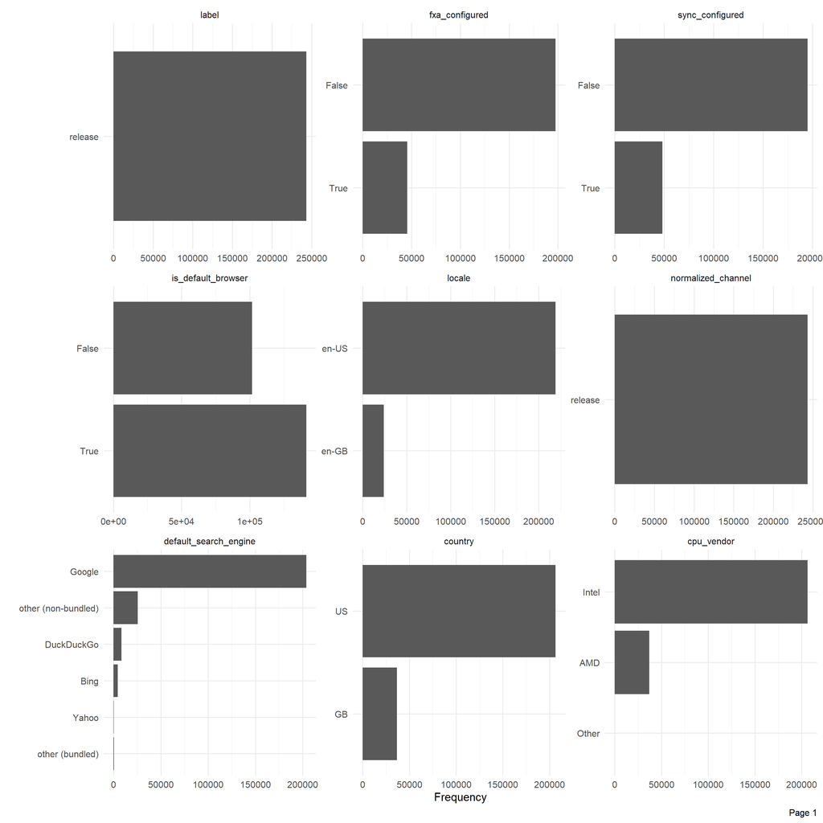

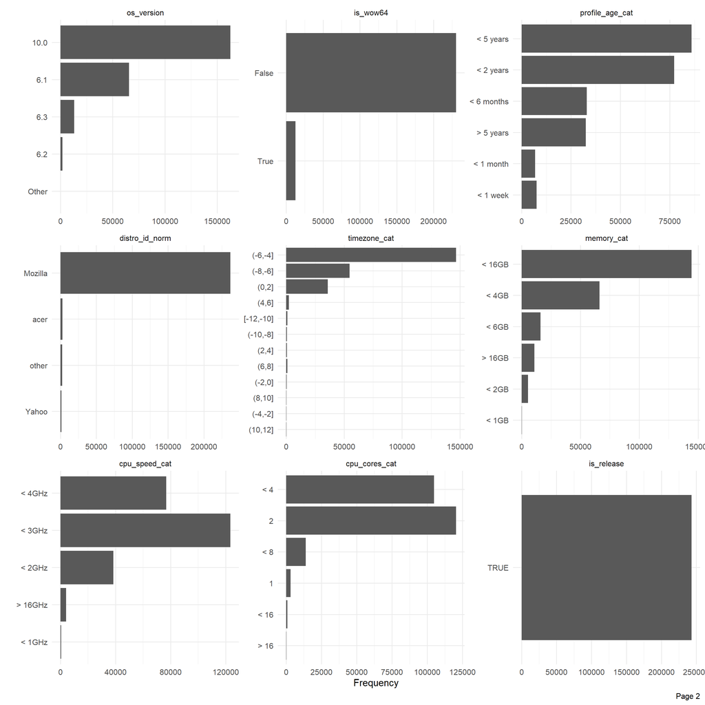

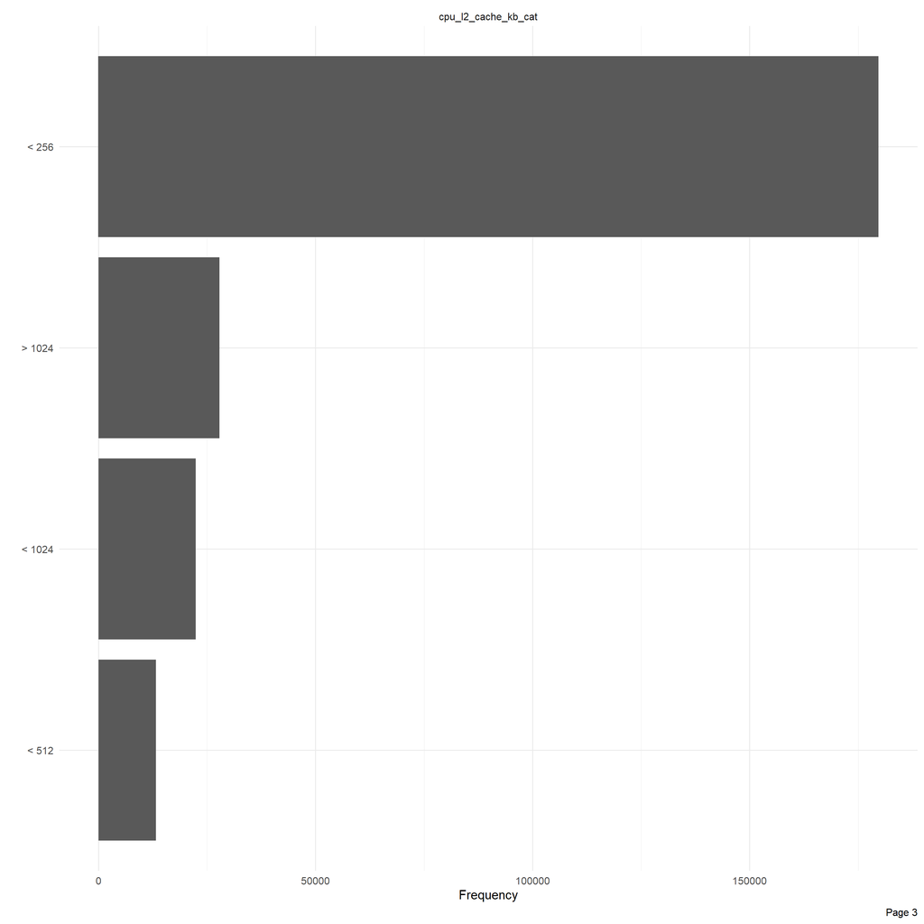

```r
## Frequency distribution release dataframe
plot_bar(df_release, ggtheme = theme_minimal(base_size = 15))
```

```
## 1 columns ignored with more than 50 categories.
## client_id: 59627 categories
```

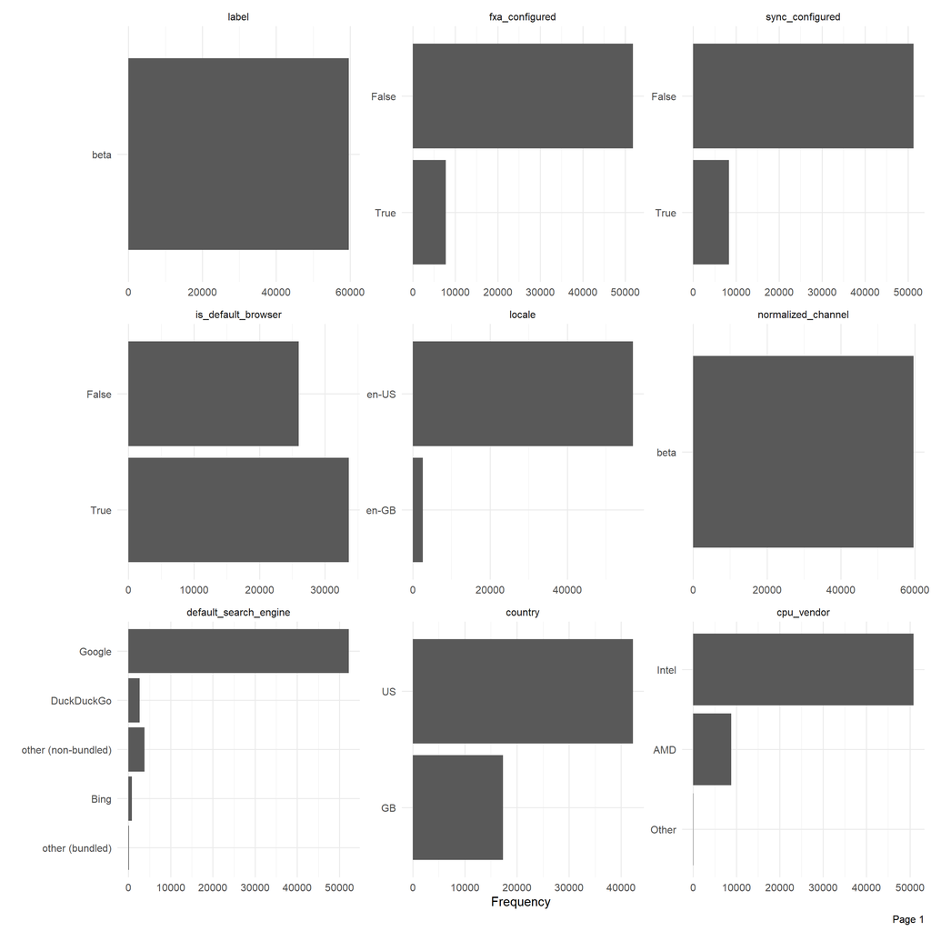

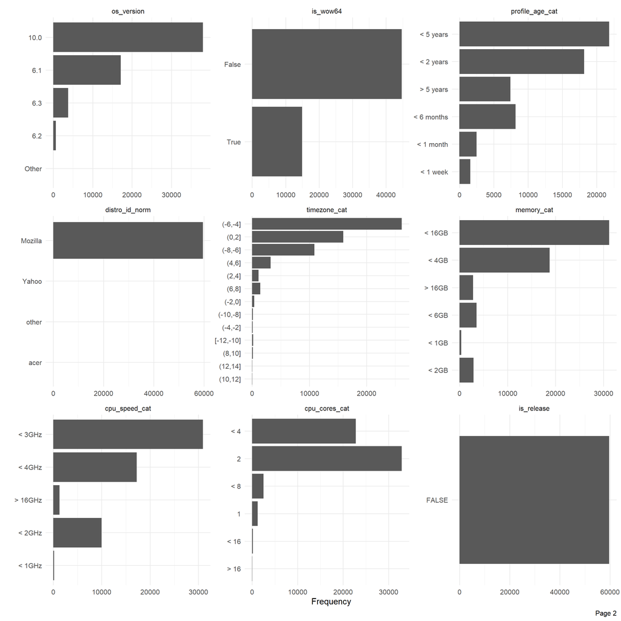

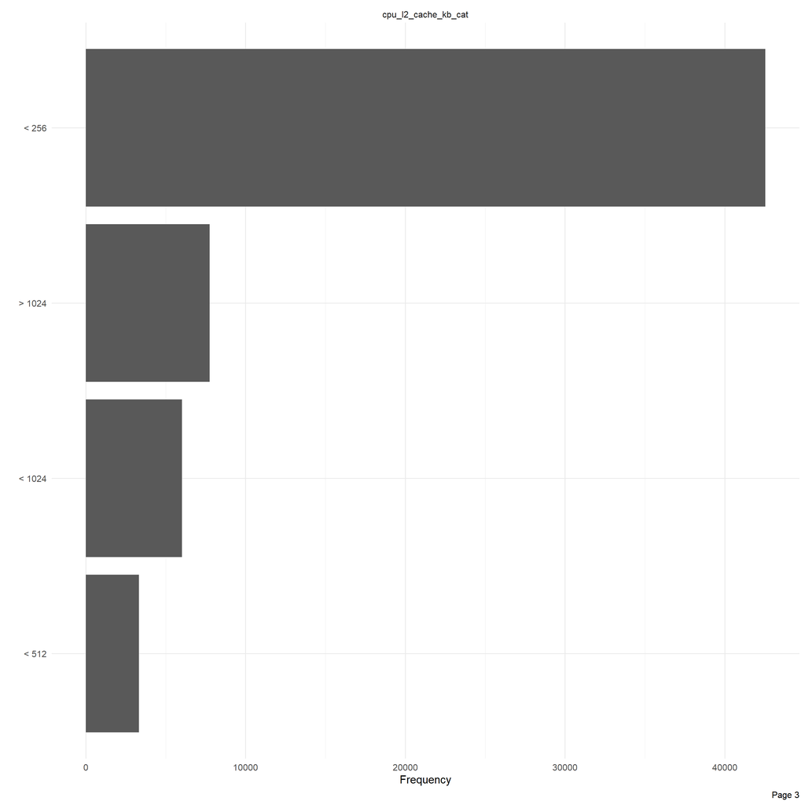

```r
## Frequency distribution beta dataframe
plot_bar(df_beta, ggtheme = theme_minimal(base_size = 15))
```

## Step 4 - Analyzing Continuos Variables

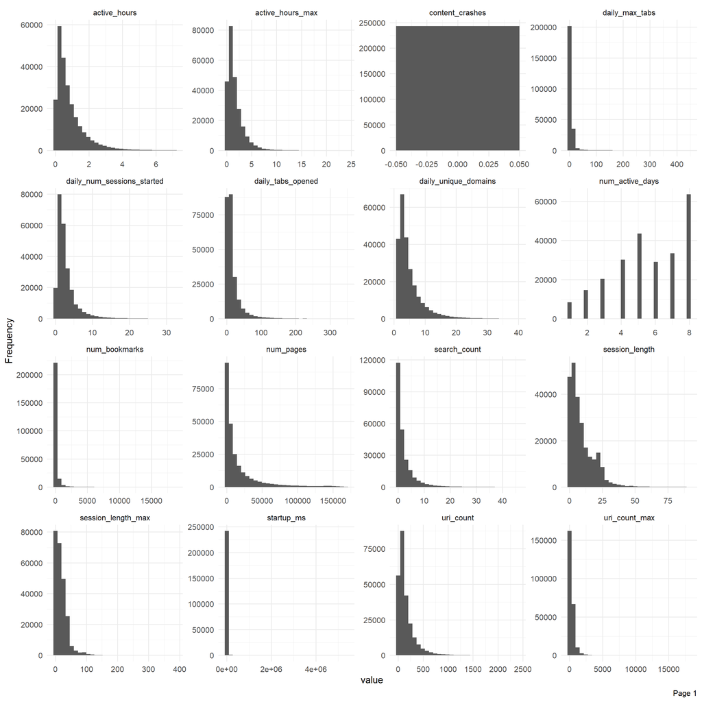

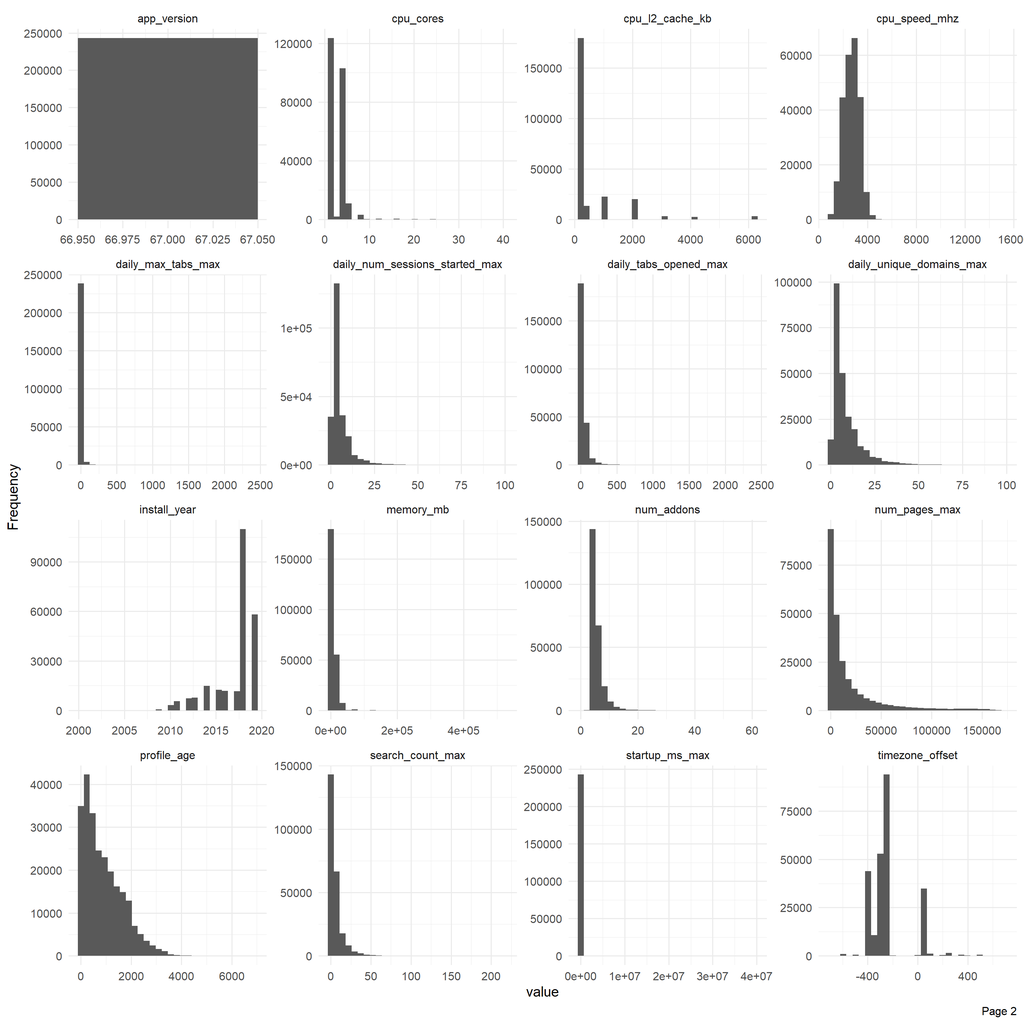

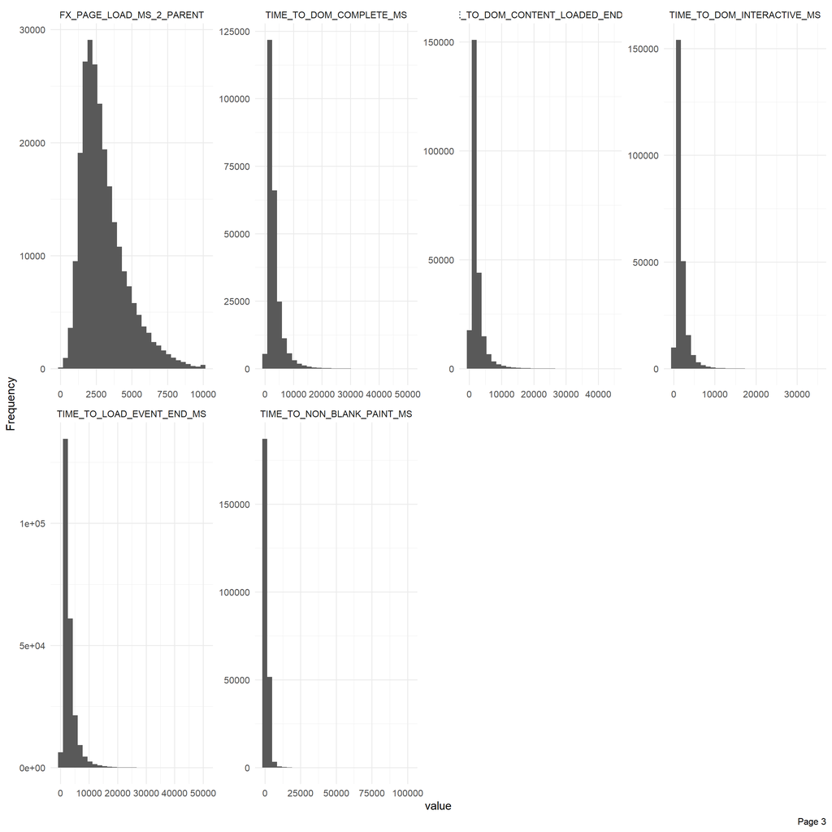

```r
## View histogram of release dataset
plot_histogram(df_release, ggtheme = theme_minimal(base_size = 15))
```

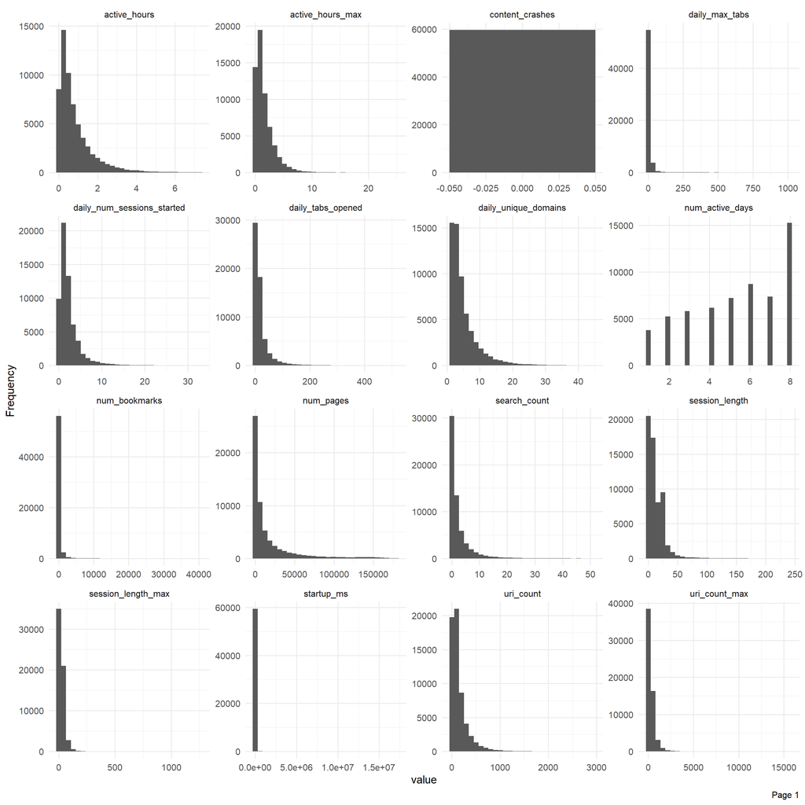

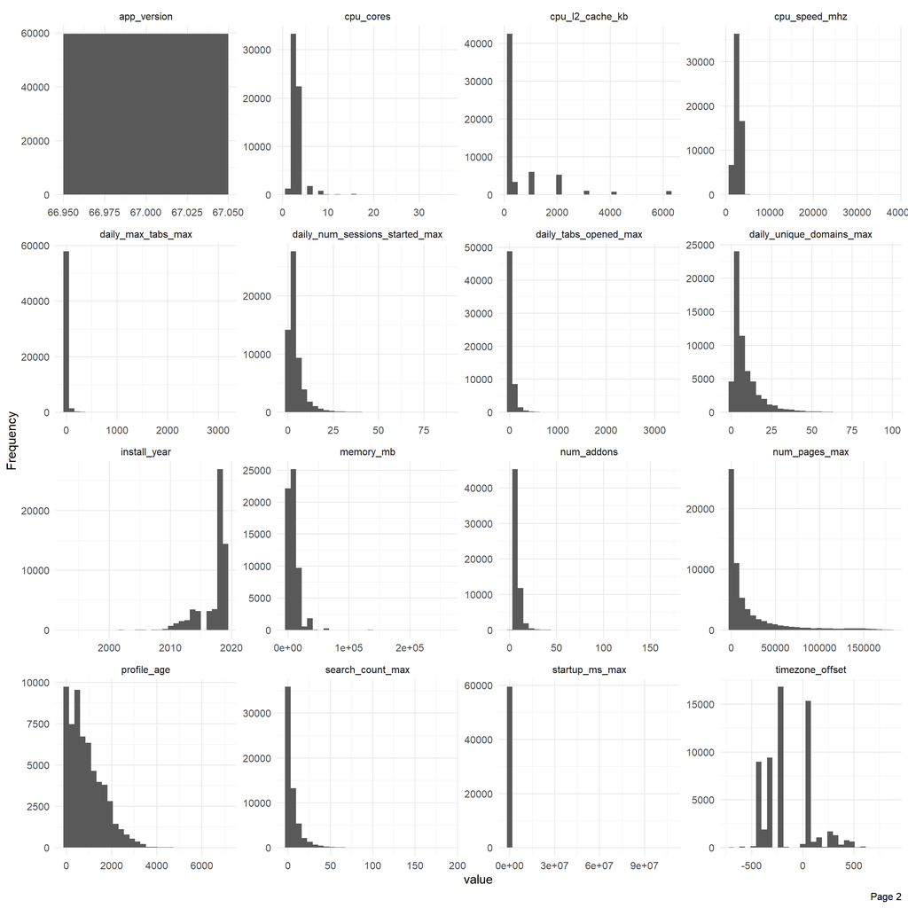

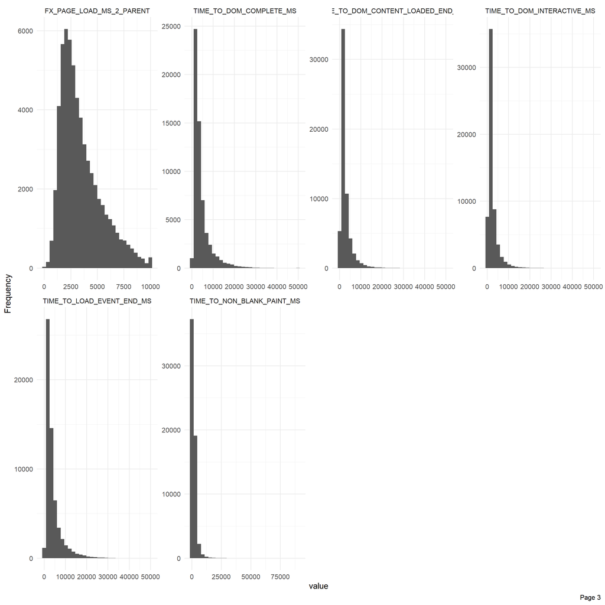

```r
## View histogram of beta dataset
plot_histogram(df_beta, ggtheme = theme_minimal(base_size = 15))
```

### Analysing User Engagement Metrics

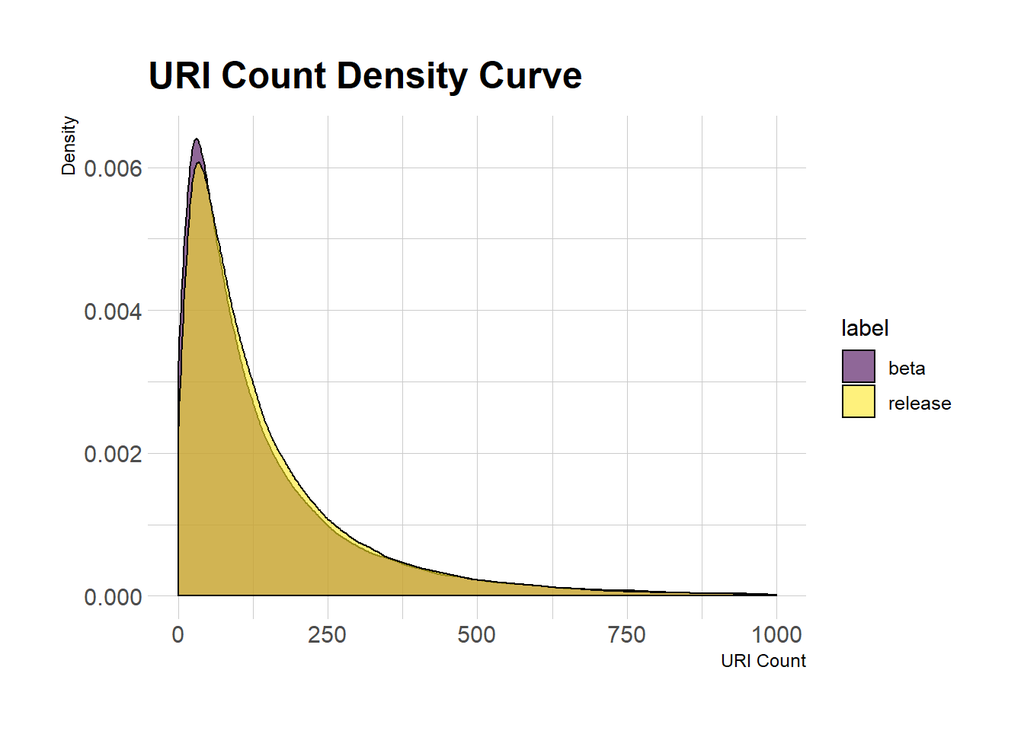

```r
ggplot(data=df_train_f, aes(x=uri_count, group=label, fill=label)) +
    geom_density(adjust=1.5, alpha=0.6) + xlim(0, 1000) +
    scale_fill_viridis(discrete=TRUE) +
    scale_color_viridis(discrete=TRUE) +
    labs(title="URI Count Density Curve",x="URI Count", y = "Density") +
    theme_ipsum()
```

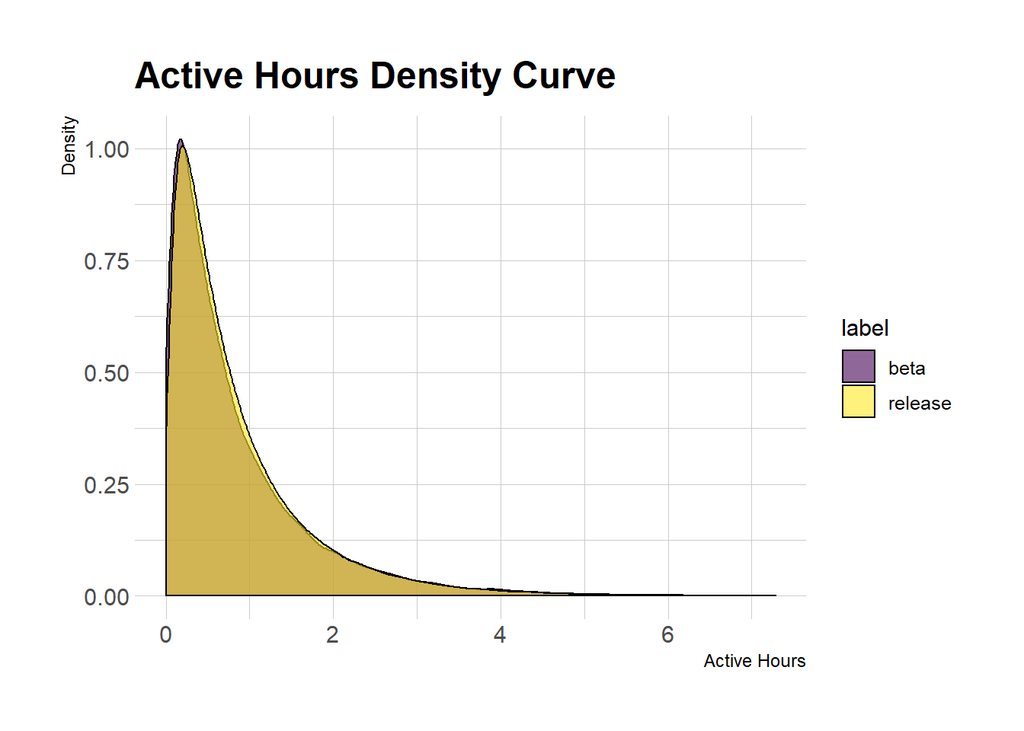

```r
ggplot(data=df_train_f, aes(x=active_hours, group=label, fill=label)) +
    geom_density(adjust=1.5, alpha=0.6) +
    scale_fill_viridis(discrete=TRUE) +
    scale_color_viridis(discrete=TRUE) +
    labs(title="Active Hours Density Curve",x="Active Hours", y = "Density") +
    theme_ipsum()
```

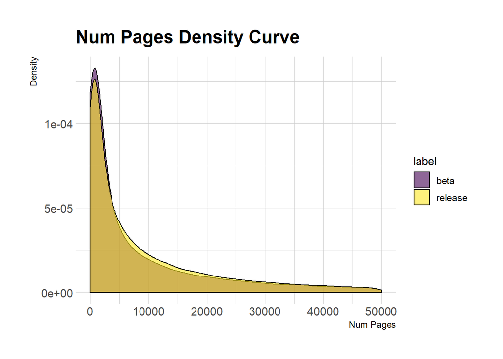

```r
ggplot(data=df_train_f, aes(x=num_pages, group=label, fill=label)) +
    geom_density(adjust=1.5, alpha=0.6) + xlim(0, 50000) +
    scale_fill_viridis(discrete=TRUE) +
    scale_color_viridis(discrete=TRUE) +
    labs(title="Num Pages Density Curve",x="Num Pages", y = "Density") +
    theme_ipsum()
```

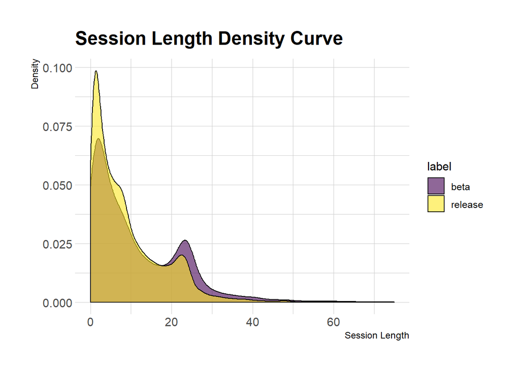

```r
ggplot(data=df_train_f, aes(x=session_length, group=label, fill=label)) +
    geom_density(adjust=1.5, alpha=0.6, main="Session Length") + xlim(0, 75) +
    scale_fill_viridis(discrete=TRUE) +
    scale_color_viridis(discrete=TRUE) +
    labs(title="Session Length Density Curve",x="Session Length", y = "Density") +
    theme_ipsum()
```

# User Engagement Metrics

This project will focus on user engagement metrics to ensure the most performant model possible.

```r
colnames(df_train_f)
```

```
##  [1] "client_id"
##  [2] "num_active_days"
##  [3] "content_crashes"
##  [4] "active_hours"
##  [5] "uri_count"
##  [6] "session_length"
##  [7] "search_count"
##  [8] "num_bookmarks"
##  [9] "num_pages"
## [10] "daily_unique_domains"
## [11] "daily_max_tabs"
## [12] "daily_tabs_opened"
## [13] "startup_ms"
## [14] "daily_num_sessions_started"
## [15] "active_hours_max"
```

[output cut: 43 more lines]

So, we are going to analyze the following metrics:

- `num_active_days`
- `active_hours`
- `active_hours_max`
- `uri_count`
- `uri_count_max`
- `session_length`
- `session_length_max`
- `search_count`
- `search_count_max`
- `num_bookmarks`
- `num_pages`
- `num_pages_max`
- `daily_unique_domains`
- `daily_max_tabs`
- `daily_tabs_opened`
- `daily_num_sessions_started`
- `daily_unique_domains_max`
- `daily_max_tabs_max`
- `daily_tabs_opened_max`
- `daily_num_sessions_started_max`

## Comparing Two Distributions

The QQ plot can be used to compare two continuous distributions.

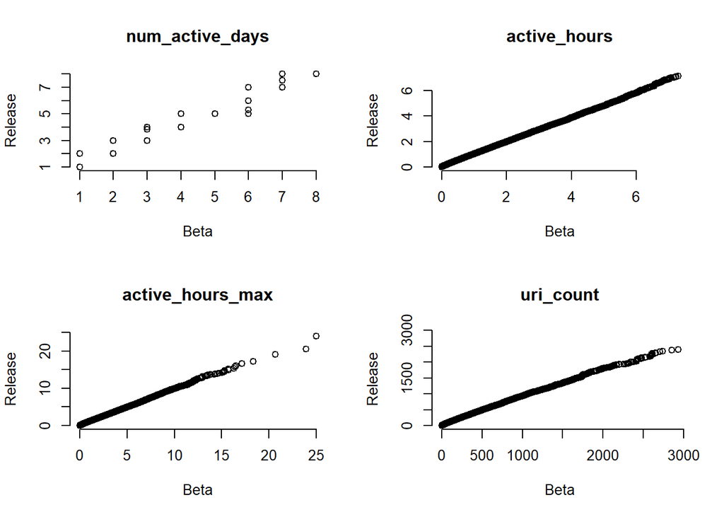

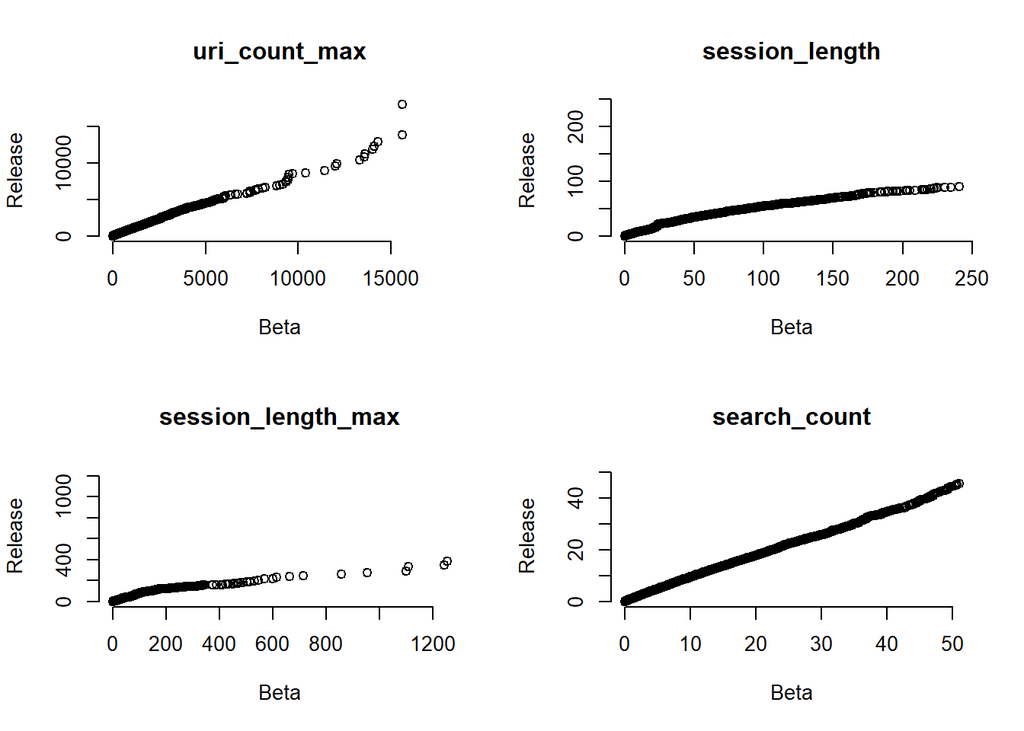

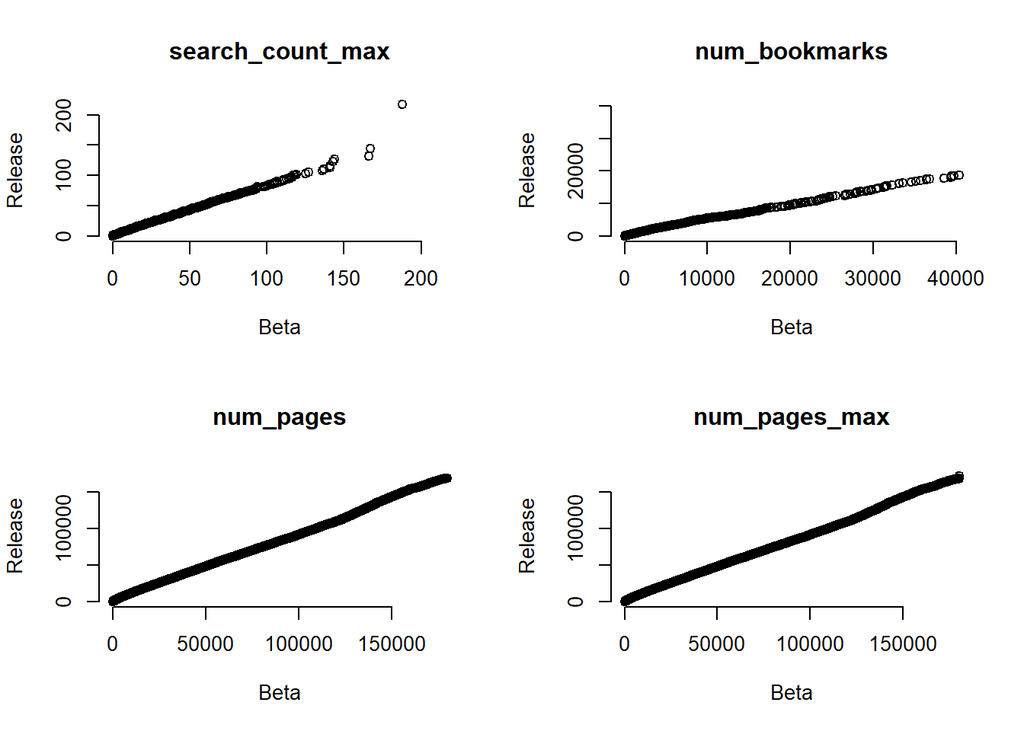

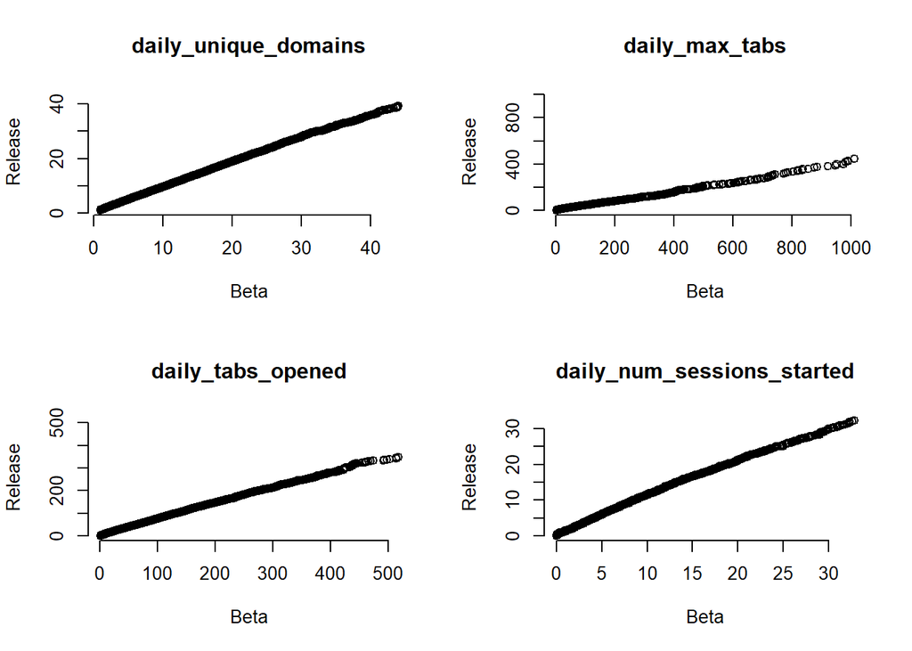

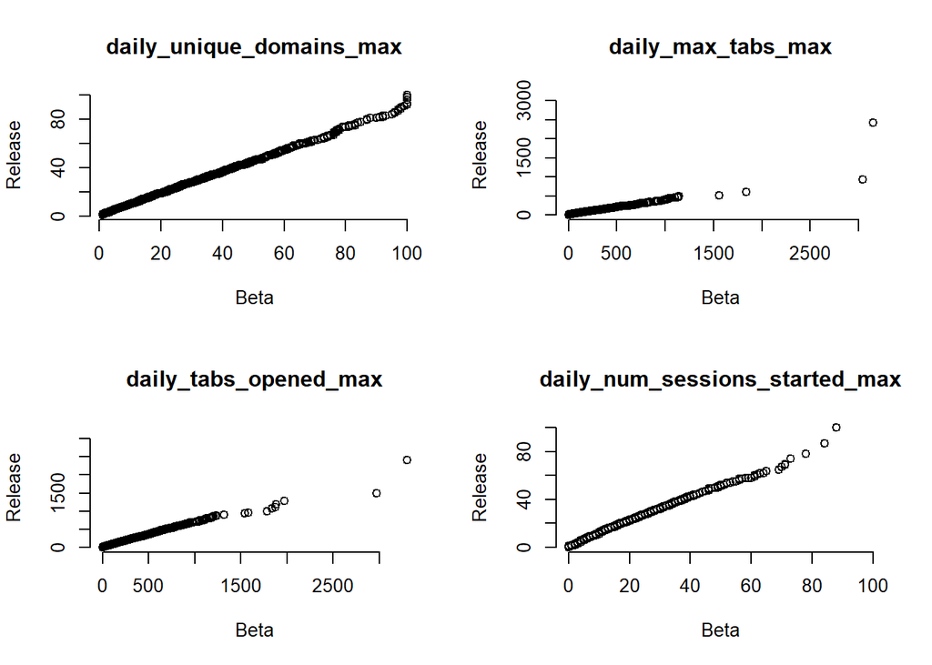

```r
par(mfrow = c(2, 2))  ## Set up a 2 x 2 plotting space

## QQ plot in R to compare two data samples
for (i in user_eng) {
  x <- df_beta_ue[,i]
  y <- df_release_ue[,i]

  rg <- range(x, y, na.rm=T)

  qqplot(x, y, main=i, xlim=rg, ylim=rg, xlab = "Beta", ylab = "Release", pch = 1, frame = FALSE)
}
```

```r
kable(text_tbl) %>%
kable_styling(bootstrap_options = c("striped", "hover", "condensed"), full_width = F) %>%
scroll_box(width = "100%")
```

|  | beta_num_active_days | release_num_active_days | beta_active_hours | release_active_hours | beta_active_hours_max | release_active_hours_max | beta_uri_count | release_uri_count | beta_uri_count_max | release_uri_count_max | beta_session_length | release_session_length | beta_session_length_max | release_session_length_max | beta_search_count | release_search_count | beta_search_count_max | release_search_count_max | beta_num_bookmarks | release_num_bookmarks | beta_num_pages | release_num_pages | beta_num_pages_max | release_num_pages_max | beta_daily_unique_domains | release_daily_unique_domains | beta_daily_max_tabs | release_daily_max_tabs | beta_daily_tabs_opened | … |
| --- | --- | --- | --- | --- | --- | --- | --- | --- | --- | --- | --- | --- | --- | --- | --- | --- | --- | --- | --- | --- | --- | --- | --- | --- | --- | --- | --- | --- | --- | --- |
| Min. | 1.000000 | 1.000000 | 0.0000000 | 0.0000000 | 0.000000 | 0.0000000 | 1.00000 | 1.00000 | 1.0000 | 1.0000 | 0.0166665 | 0.0192595 | 0.021389 | 0.030556 | 0.0000000 | 0.000000 | 0.000000 | 0.000000 | 0.0000 | 0.0000 | 1.000 | 0.000 | 1.00 | 0.00 | 1.000000 | 1.000000 | 1.000000 | 0.625000 | 1.00000 | … |
| 1st Qu. | 4.000000 | 4.000000 | 0.2250000 | 0.2686111 | 0.450000 | 0.5402778 | 37.00000 | 44.33333 | 68.0000 | 86.0000 | 2.5284028 | 2.1590431 | 4.877777 | 4.408542 | 0.0000000 | 0.000000 | 0.000000 | 0.000000 | 10.0000 | 10.0000 | 686.000 | 1022.125 | 785.00 | 1142.00 | 2.166667 | 2.283333 | 2.600000 | 2.500000 | 4.00000 | … |
| Median | 6.000000 | 6.000000 | 0.5309524 | 0.5744444 | 1.063889 | 1.1541667 | 86.66667 | 96.66667 | 172.0000 | 196.0000 | 7.7105554 | 6.3351191 | 14.808889 | 11.701666 | 0.8333333 | 0.875000 | 2.000000 | 2.000000 | 26.0000 | 26.0000 | 4185.667 | 5536.000 | 4340.00 | 5705.50 | 3.562500 | 3.600000 | 4.250000 | 3.714286 | 9.00000 | … |
| Mean | 5.346169 | 5.569842 | 0.8236611 | 0.8468557 | 1.577508 | 1.6251135 | 152.74550 | 156.24224 | 311.0213 | 321.3891 | 12.2961990 | 9.2821806 | 22.706568 | 18.210749 | 2.4506498 | 2.376504 | 5.636171 | 5.434352 | 242.4878 | 158.9390 | 17363.463 | 17330.600 | 17558.93 | 17518.75 | 5.060464 | 4.968328 | 9.603628 | 6.200080 | 20.49191 | … |
| 3rd Qu. | 8.000000 | 8.000000 | 1.1028646 | 1.1265956 | 2.165278 | 2.1902778 | 188.50000 | 197.00000 | 382.0000 | 400.0000 | 19.5792560 | 13.6608531 | 31.519026 | 26.128403 | 2.8333333 | 3.000000 | 7.000000 | 7.000000 | 96.0000 | 85.2125 | 18605.464 | 19680.625 | 18885.50 | 19922.00 | 6.166667 | 6.070833 | 8.000000 | 6.000000 | 21.75000 | … |
| Max. | 8.000000 | 8.000000 | 7.2901042 | 7.1222222 | 24.983333 | 23.9666667 | 2931.00000 | 2391.25000 | 15626.0000 | 18032.0000 | 240.8048605 | 91.0663890 | 1255.382223 | 384.288333 | 51.0000000 | 45.750000 | 188.000000 | 217.000000 | 40401.0000 | 18632.0000 | 179657.500 | 168416.286 | 180456.00 | 172543.00 | 44.000000 | 39.375000 | 1012.625000 | 445.375000 | 518.25000 | … |